# Machine Learning: Mathematical Theory and Applications

Computer lab 2

Thu Trang Tran

Published

September 1, 2026

**Warning**

The instructions in this lab assume that the following packages are installed:

For Part I:

- `splines`
- `dplyr`
- `caret`

For Part II:

- `keras` (note: may require some effort to install, see below)
- `dplyr`
- `caret`
- `pROC`
- `pracma`
- `splines`
- `grid`
- `mvtnorm`

Packages may be installed by executing `install.packages('packagename')`, where `'packagename'` is the name of the package, e.g. `'splines'`. You may have to install additional packages to solve the computer lab. If you want this file to run locally on your computer, you have to change some paths to where the data are stored (see below).

## Introduction

This computer lab covers Modules 2 (Part I) and 3 (Part II). Part I treats topics such as bagging, boosting, and learning parametric models by several optimisation algorithms. Part II treats topics such as dense neural networks, convolutional neural networks, and Gaussian processes.

## 1. Bagging and boosting for bike rental data (regression)

Bagging = Boostrap + Aggregating, bagging builds the models at the same time (less time), use the bootstrap data subset from the original. When taking the average of the model, bagging treat them as equals

Boosting = start with a classifier -> result in some right and wrong prediction -> train a new classifier with upweighted wrong ones previously, repeat till converge

Boosting builds them sequentially (more time), use the same data set, put more weight on the incorrectly predicted ones, boosting take average of the models, with more weights on the better performance models

Both methods are good at reducing the variance, but for bagging there is almost no bias reduction because it doesn’t weight the data when sampling, the bias of each individual model is transferred to the final model. Meanwhile, boosting does reduce bias because it weight the data for each model. However, this makes boosting more prone to overfitting.

The dataset contains 17379 hourly observations over the two-year period January 1, 2011 - December 31, 2012. The dataset contains many features that may be useful for predicting the number of rides, such as the hour of the day, temperature, humidity, season, weekday, etc. In this section, we use the dataset that in addition contains features that capture the time series characteristics of the data. The following code builds that dataset, where we use the same training and test data as in Problem 4.2 in Computer lab 1.

```r
#rm(list=ls()) # Remove variables
#cat("\014") # Clean workspace
suppressMessages(library(dplyr))
suppressMessages(library(splines))
bike_data <- read.csv('C:/Users/asus/Desktop/Machine learning/Lab 2/bike_rental_hourly.csv') # Changed file location

head(bike_data)
```

```
  instant     dteday season yr mnth hr holiday weekday workingday weathersit
1       1 2011-01-01      1  0    1  0       0       6          0          1
2       2 2011-01-01      1  0    1  1       0       6          0          1
3       3 2011-01-01      1  0    1  2       0       6          0          1
4       4 2011-01-01      1  0    1  3       0       6          0          1
5       5 2011-01-01      1  0    1  4       0       6          0          1
6       6 2011-01-01      1  0    1  5       0       6          0          2
  temp  atemp  hum windspeed casual registered cnt
1 0.24 0.2879 0.81    0.0000      3         13  16
2 0.22 0.2727 0.80    0.0000      8         32  40
3 0.22 0.2727 0.80    0.0000      5         27  32
4 0.24 0.2879 0.75    0.0000      3         10  13
5 0.24 0.2879 0.75    0.0000      0          1   1
6 0.24 0.2576 0.75    0.0896      0          1   1
```

```r
bike_data$log_cnt <- log(bike_data$cnt)
bike_data$hour <- bike_data$hr/23 # transform [0, 23] to [0, 1]. 0 is midnight, 1 is 11 PM

# One hot for weathersit
one_hot_encode_weathersit <- model.matrix(~ as.factor(weathersit) - 1,data = bike_data)
one_hot_encode_weathersit  <- one_hot_encode_weathersit[, -1] # Remove reference category
colnames(one_hot_encode_weathersit) <- c('cloudy', 'light rain', 'heavy rain')
bike_data <- cbind(bike_data, one_hot_encode_weathersit)

# One hot for weekday
one_hot_encode_weekday <- model.matrix(~ as.factor(weekday) - 1,data = bike_data)
one_hot_encode_weekday  <- one_hot_encode_weekday[, -1] # Remove reference category
colnames(one_hot_encode_weekday) <- c('Mon', 'Tue', 'Wed', 'Thu', 'Fri', 'Sat')
bike_data <- cbind(bike_data, one_hot_encode_weekday)

# One hot for weekday
one_hot_encode_season <- model.matrix(~ as.factor(season) - 1,data = bike_data)
one_hot_encode_season  <- one_hot_encode_season[, -1] # Remove reference category
colnames(one_hot_encode_season) <- c('Spring', 'Summer', 'Fall')
bike_data <- cbind(bike_data, one_hot_encode_season)

# Create lags
bike_data_new <- mutate(bike_data, lag1 = lag(log_cnt, 1), lag2 = lag(log_cnt, 2),
                        lag3 = lag(log_cnt, 3), lag4 = lag(log_cnt, 4), lag24 = lag(log_cnt, 24))

bike_data_new <- bike_data_new[-c(1:24),] # Lost 24 obs because of lagging

# Create training and test data
bike_all_data_train <- bike_data_new[bike_data_new$dteday >= as.Date("2011-01-01") & bike_data_new$dteday <=  as.Date("2012-05-31"), ]
bike_all_data_test <- bike_data_new[bike_data_new$dteday >= as.Date("2012-06-01") & bike_data_new$dteday <=  as.Date("2012-12-31"), ]
X_train <- cbind(1, bike_all_data_train[, c("lag1", "lag2",  "lag3", "lag4", "lag24")])
spline_basis <- ns(bike_all_data_train$hour, df = 10, intercept = FALSE)
X_train <- cbind(X_train, spline_basis)
colnames(X_train)[1] <- "intercept"
knots <- attr(spline_basis, "knots")
variables_to_keep_in_X <- c("yr", "holiday", "workingday", "temp", "atemp", "hum", "windspeed")
variables_to_keep_in_X <- c(variables_to_keep_in_X, colnames(one_hot_encode_weathersit), colnames(one_hot_encode_weekday), colnames(one_hot_encode_season))
X_train <- cbind(X_train, bike_all_data_train[, variables_to_keep_in_X])
head(X_train)
```

```
   intercept     lag1     lag2     lag3     lag4    lag24          1          2
25         1 3.663562 3.332205 3.526361 3.583519 2.772589 0.00000000 0.00000000
26         1 2.833213 3.663562 3.332205 3.526361 3.688879 0.01785714 0.00000000
27         1 2.833213 2.833213 3.663562 3.332205 3.465736 0.14285714 0.00000000
28         1 2.197225 2.833213 2.833213 3.663562 2.564949 0.41785714 0.01428571
29         1 1.791759 2.197225 2.833213 2.833213 0.000000 0.62857143 0.11428571
30         1 1.098612 1.791759 2.197225 2.833213 0.000000 0.34285714 0.58095238
            3 4 5 6 7            8           9           10 yr holiday
25 0.00000000 0 0 0 0  0.000000000 0.000000000  0.000000000  0       0
26 0.00000000 0 0 0 0 -0.116963312 0.350889936 -0.233926624  0       0
27 0.00000000 0 0 0 0 -0.175067667 0.525203001 -0.350135334  0       0
28 0.00000000 0 0 0 0 -0.138695850 0.416087550 -0.277391700  0       0
29 0.00000000 0 0 0 0 -0.065197614 0.195592842 -0.130395228  0       0
30 0.06666667 0 0 0 0 -0.002414726 0.007244179 -0.004829453  0       0
   workingday temp  atemp  hum windspeed cloudy light rain heavy rain Mon Tue
25          0 0.46 0.4545 0.88    0.2985      1          0          0   0   0
26          0 0.44 0.4394 0.94    0.2537      1          0          0   0   0
27          0 0.42 0.4242 1.00    0.2836      1          0          0   0   0
28          0 0.46 0.4545 0.94    0.1940      1          0          0   0   0
29          0 0.46 0.4545 0.94    0.1940      1          0          0   0   0
30          0 0.42 0.4242 0.77    0.2985      0          1          0   0   0
   Wed Thu Fri Sat Spring Summer Fall
25   0   0   0   0      0      0    0
26   0   0   0   0      0      0    0
27   0   0   0   0      0      0    0
28   0   0   0   0      0      0    0
29   0   0   0   0      0      0    0
30   0   0   0   0      0      0    0
```

```r
# Training data
X_train <- as.matrix(X_train)
y_train <- bike_all_data_train$log_cnt
# Test data
y_test <- bike_all_data_test$log_cnt
X_test <- cbind(1, bike_all_data_test[, c("lag1", "lag2",  "lag3", "lag4", "lag24")])
spline_basis_test <- ns(bike_all_data_test$hour, df=10, knots=knots, intercept = FALSE)
X_test <- cbind(X_test, spline_basis_test)
colnames(X_test)[1] <- "intercept"
X_test <- cbind(X_test, bike_all_data_test[, variables_to_keep_in_X])
X_test <- as.matrix(X_test)
```

#### 💪 Problem 1.1

Use the `randomForest()` function in the `randomForest` package to fit three random forest regressions (bagging algorithms) with the `ntree` argument set to, respectively, 50, 100, and 500 (number of trees to grow). In each case, compute the root mean squared error (RMSE) for the training and test datasets.

**Tip**

The `predict()` function can be used on the object returned by `randomForest()`. The predict function has an argument `newdata`, which is used to specify the features to predict for.

```r
suppressMessages(library(randomForest))
suppressMessages(library(glue)) # For displaying mixed strings in cat
```

```r
# Convert X_train and X_test into data frame
X_train_1.1 <- as.data.frame(X_train)
X_test_1.1<- as.data.frame(X_test)

# Fit 3 random forest models in a for loop
ntree = c(50, 100, 500)
set.seed(0) # setting seed inside the loop can result in the first 50 tree of 100 and 500-tree forests all the same

for (x in ntree)
{
  random_forest <- randomForest(x = X_train_1.1, y = y_train, ntree = x) # better fit for regression tree
  y_train_predict <- predict(random_forest, newdata = X_train)
  y_test_predict <- predict(random_forest, newdata = X_test)

  RMSE_train <- sqrt(mean((y_train_predict - y_train)^2))
  RMSE_test <- sqrt(mean((y_test_predict - y_test)^2))

 cat(glue("{x}-tree forest\nRMSE train: {RMSE_train}\nRMSE test: {RMSE_test}\n\n\n"))}
```

```
50-tree forest
RMSE train: 0.145128740833416
RMSE test: 0.294277201420351

100-tree forest
RMSE train: 0.14186431763352
RMSE test: 0.294305379562485

500-tree forest
RMSE train: 0.139645233397716
RMSE test: 0.290588948033843
```

#### 💪 Problem 1.2

Plot a time series plot of the response in the original scale (i.e. counts and not log-counts) for the last week of the test data (last $24\times 7$ observations). In the same figure, plot a time series plot of the fitted values (in the original scale) from Problem 1.1 when using `ntree=50` and `ntree=100.` Comment on the results.

```r
#Create the data set for last week of data
bike_data_last_week <- tail(bike_all_data_test, 168)
```

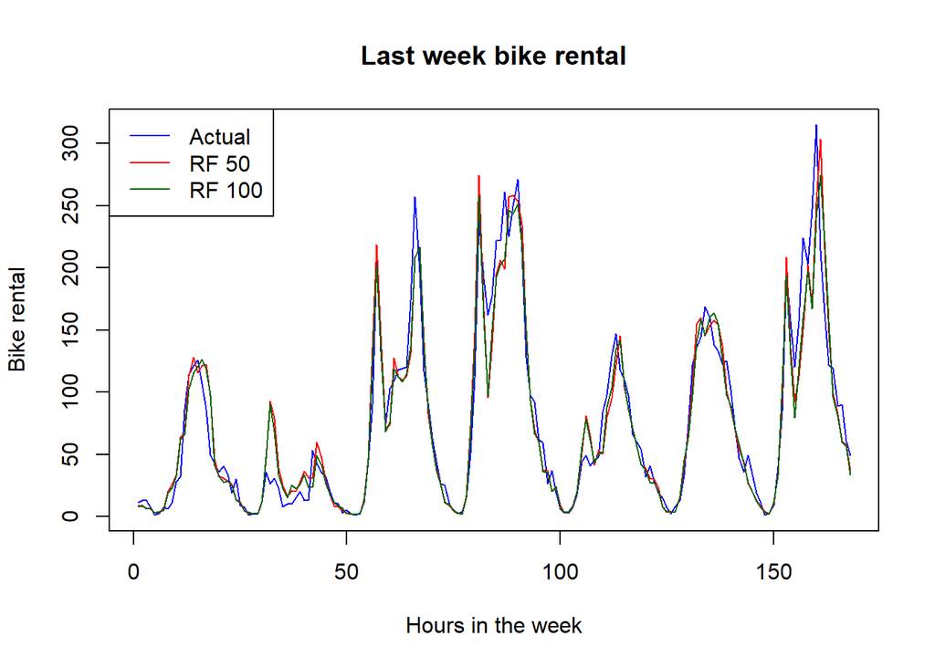

```r
# Format x axis in dataset
bike_data_last_week$dteday <- as.Date(bike_data_last_week$dteday)

# Plot a time series plot of the response in the original scale for the last week of the test data
plot(bike_data_last_week$cnt, xlab = "Hours in the week", ylab = "Bike rental", type = "l", col="blue", main = "Last week bike rental", lwd = 1 )

# Recreate the fitted values from 1.1 for 50 and 100-tree forests
ntree = c(50,100)
set.seed(0)
for (x in ntree)
{
  random_forest <- randomForest(X_train_1.1, y_train, ntree = x)
  y_test_predict <- tail(predict(random_forest, newdata = X_test),168) # take the last 168 values of y test, these are the logcnt values
  y_test_predict_cnt <- exp(y_test_predict) # convert logcnt values into cnt values
  # Plot the fitted values from 1.1 for cnt values
  if (x == 50) # 50-tree forest
  {lines(y_test_predict_cnt, lwd = 1, col = "red")}
  else {lines(y_test_predict_cnt, lwd = 1, col = "darkgreen")} # 100-tree forest
}
# Add legend
legend("topleft", legend = c("Actual", "RF 50", "RF 100"), col = c("blue", "red", "darkgreen"), lty = c(1, 1, 1), lwd = 1)
```

**Note**